# Лабораторная работа №9

Операционные системы

Чистов Д. М.

Российский университет дружбы народов, Москва, Россия

6 Апреля 2024

# Вступительная информация

# Цель работы

Целью данной работы является освоение основных возможностей командной оболочки Midnight Commander. Приобретение навыков практической работы по просмотру каталогов и файлов; манипуляций с ними.

# Задание

1. Работа с Midnight Commander
2. Работа со встроенным редактором файлов в Midnight Commander

# Выполнение лабораторной работы

## 1. Работа с Midnight Commander

Приступаю к выполнению работы. Для начала изучу документацию к Midnight Commander с помощью команды man.

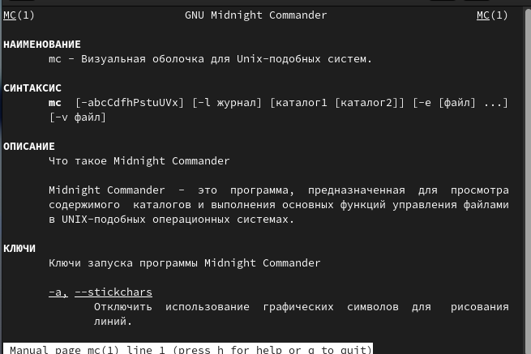

man о Midnight Commander

## 1. Работа с Midnight Commander

Ввожу в консоль команду mc и попадаю в Midnight commander. От меня требуется поработать с файлами моей операционной системы, с помощью MC.

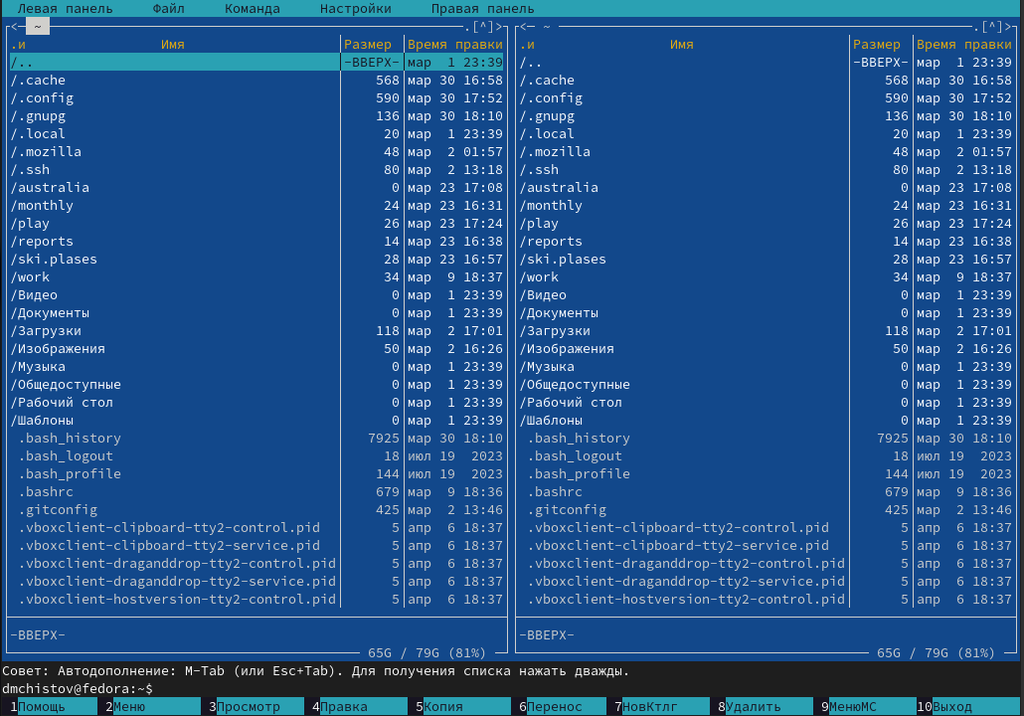

Midnight Commander

## 1. Работа с Midnight Commander

Клавишами стрелками на клавиатуре передвигаюсь по катлогом, и выбираю папку play.

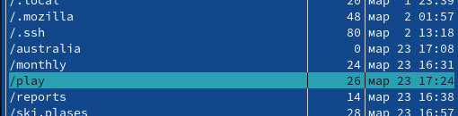

Работа с Midnight Commander

## 1. Работа с Midnight Commander

Копирую каталог play в него самого.

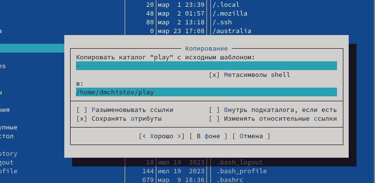

Копирование папки

## 1. Работа с Midnight Commander

Папка успешно скопирована.

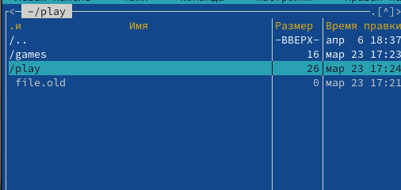

Копирование папки

## 1. Работа с Midnight Commander

В текущем каталоге создам папку.

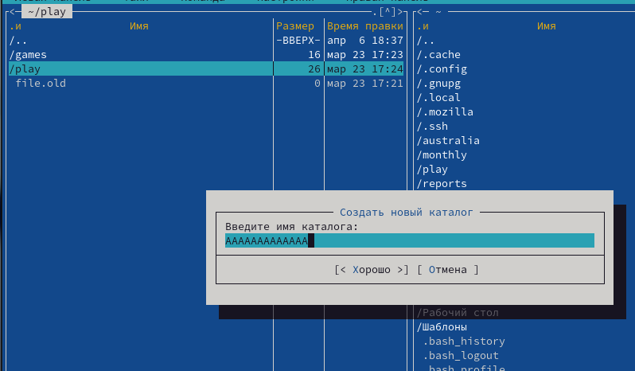

Создание папки

## 1. Работа с Midnight Commander

Папка успешно создана.

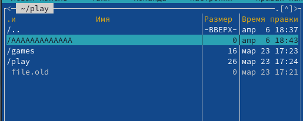

Создание папки

## 1. Работа с Midnight Commander

Перемещаю file.old в домашнюю папку.

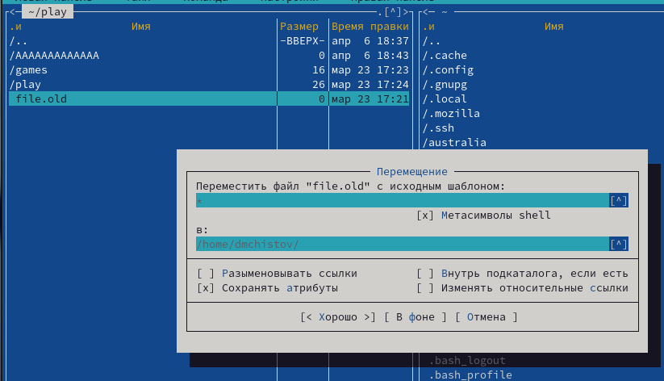

Перемещение файла

## 1. Работа с Midnight Commander

Файл успешно перенесён.

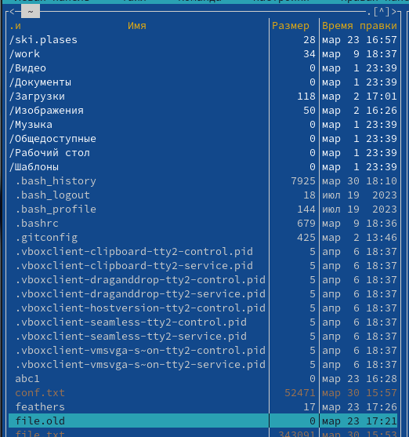

Перемещение файла

## 1. Работа с Midnight Commander

В подменю “Правая панель” выбираю “Краткий просмотр” и теперь в левой панели я могу выбирать файл, а в правой кратко на него посмотреть.

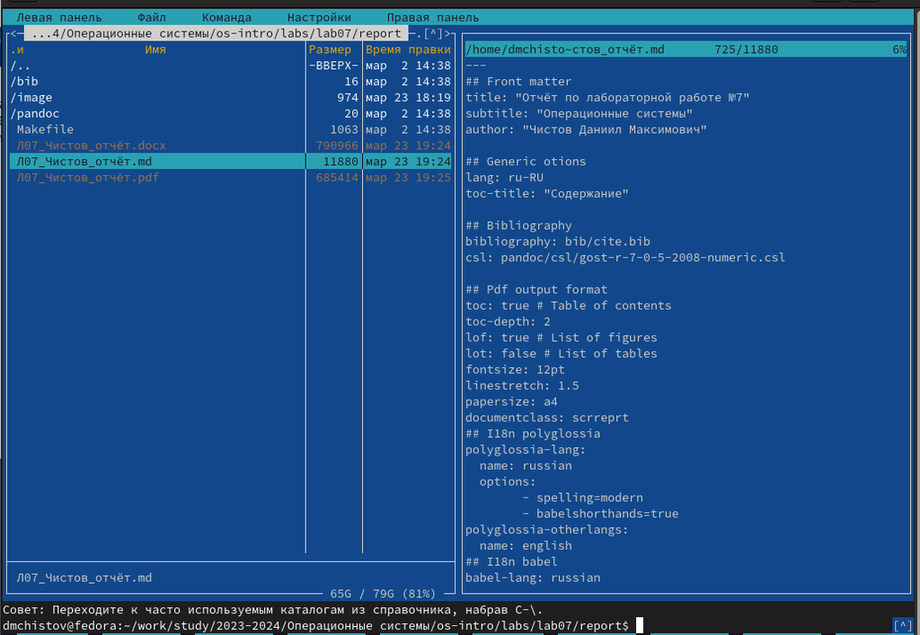

Просмотр файла в правой панели

## 1. Работа с Midnight Commander

Таким же образом я могу просмотреть особую информацию о файле, включая его положение, дату изменения, права и т.д.

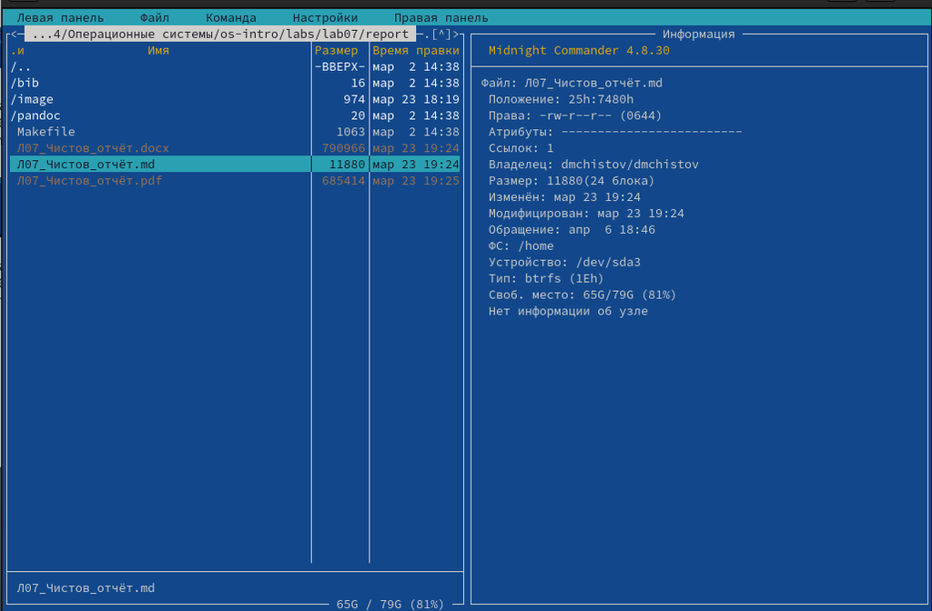

Просмотр основной информации о файле в правой панели

## 1. Работа с Midnight Commander

Используя возможности подменю “файл”: просматриваю содержимое файла.

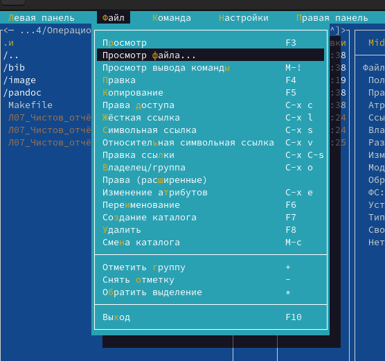

Подменю “Файл”

## 1. Работа с Midnight Commander

Успешно просматриваю содержимое файла.

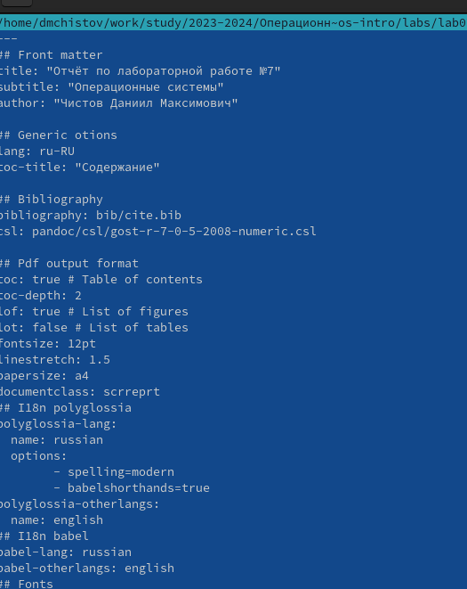

Просмотр файла

## 1. Работа с Midnight Commander

Используя возможности подменю “файл”: изменяю файл.

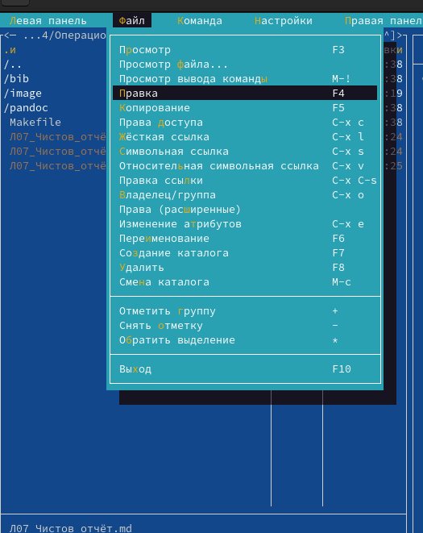

Подменю “Файл”

## 1. Работа с Midnight Commander

Успешно изменяю файл.

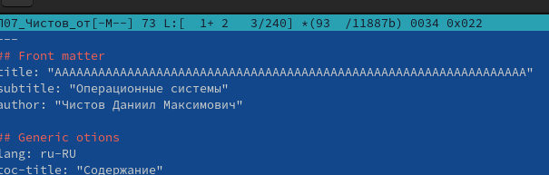

Изменение файла

## 1. Работа с Midnight Commander

Также в меню “Файл” могу создать каталог.

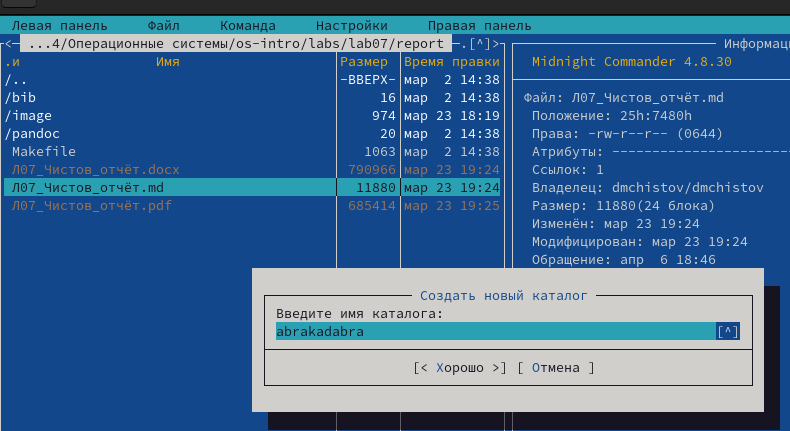

Создание каталога

## 1. Работа с Midnight Commander

Каталог успешно создан.

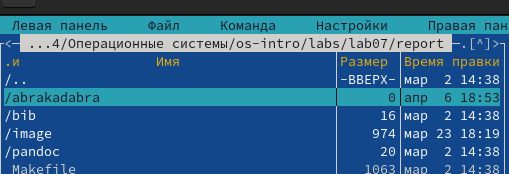

Создание каталога

## 1. Работа с Midnight Commander

Требуется скопировать несколько файлов. Для начала правой кнопкой мыши выделю нужные мне файлы.

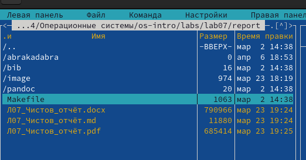

Выделение файлов

## 1. Работа с Midnight Commander

В подменю “Файл” выбираю “копирование”.

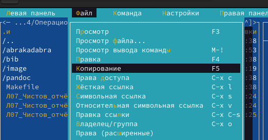

Копирование

## 1. Работа с Midnight Commander

Выбираю место, куда хочу скопировать файлы.

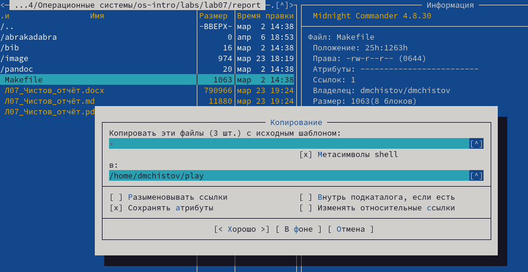

Выбор места для копирования

## 1. Работа с Midnight Commander

Файлы успешно скопированы.

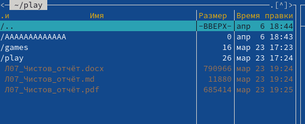

Файлы успешно скопированы

## 1. Работа с Midnight Commander

С помощью возможностей меню “Команда”: ищу нужный мне файл.

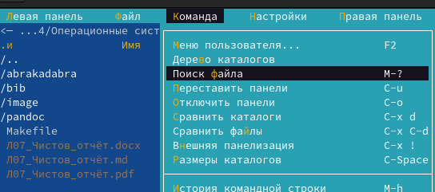

Поиск файла

## 1. Работа с Midnight Commander

Указываю .md в “содержимое”.

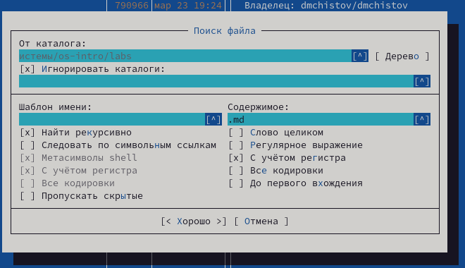

Поиск файла

## 1. Работа с Midnight Commander

Файлы успешно найдены.

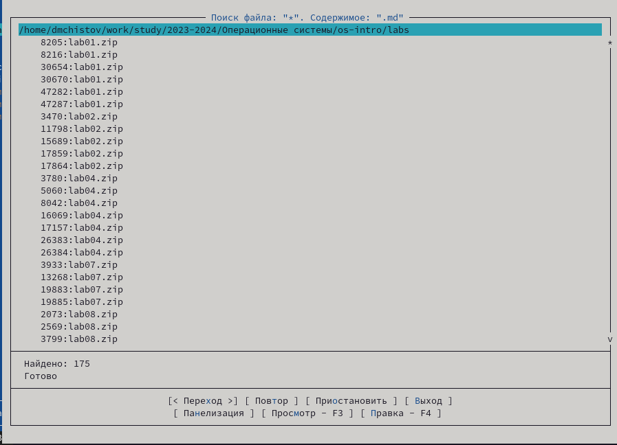

Поиск файла - успешно

## 1. Работа с Midnight Commander

Воспользуюсь историей командной строки.

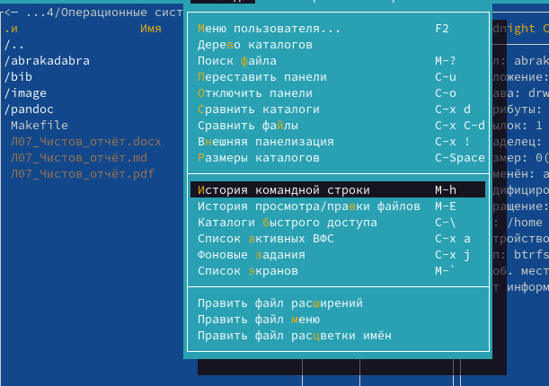

История командной строки

## 1. Работа с Midnight Commander

Анализирую файл расширений.

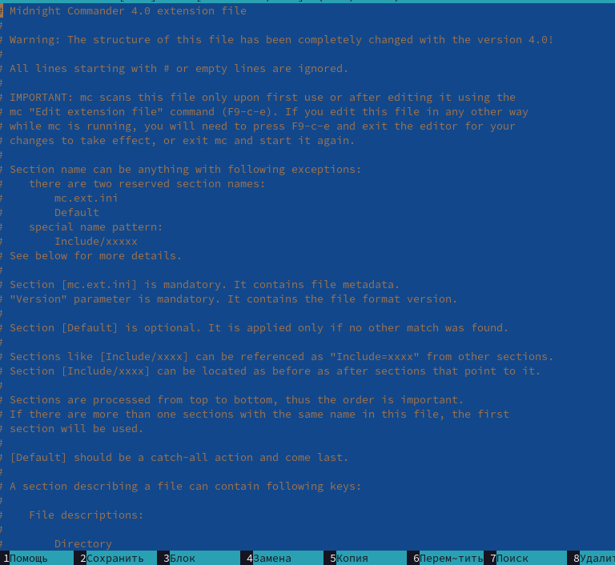

Файл расширений

## 1. Работа с Midnight Commander

Анализирую файл меню.

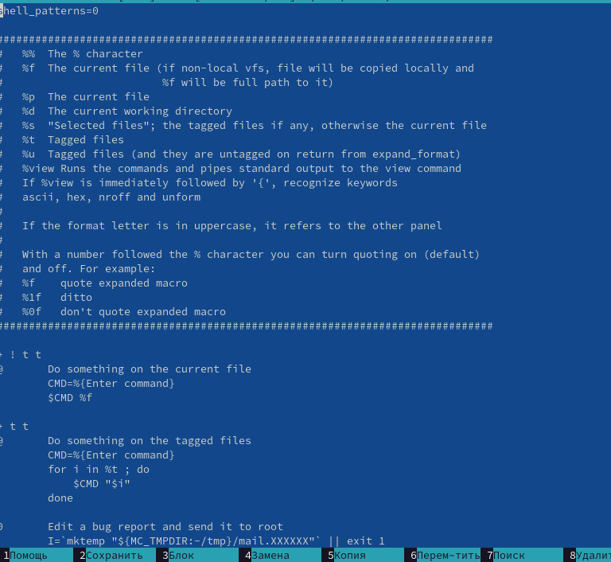

Файл меню

## 1. Работа с Midnight Commander

В меню настройках могу, например, убрать мини-статус.

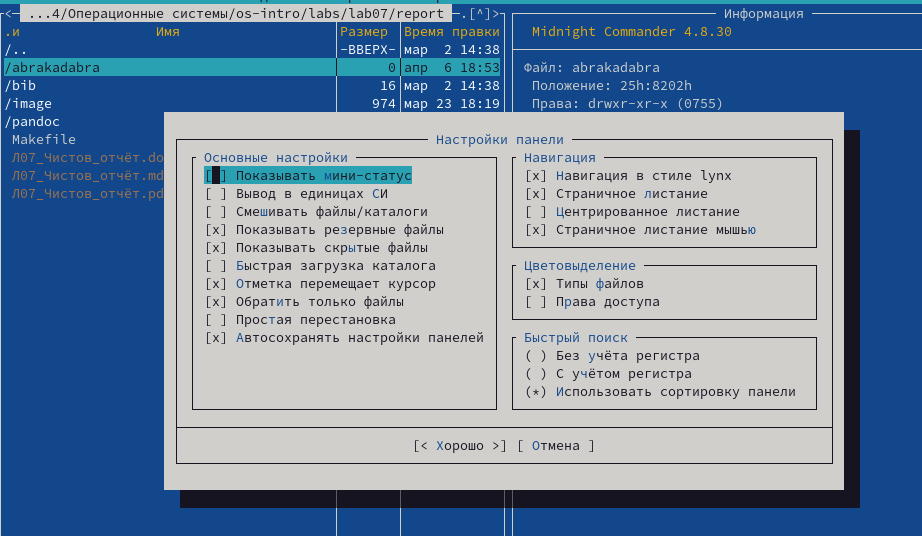

Настройки панели

## 1. Работа с Midnight Commander

Могу изменить расположение панелей в MC, выбрав “горизонатльное” в меню “Внешний вид”.

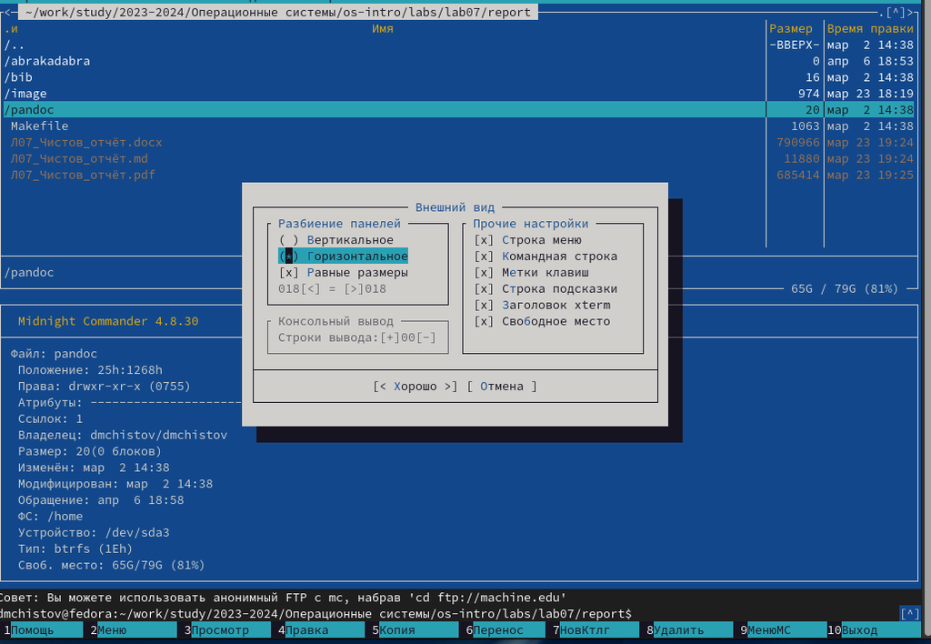

Настройки внешнего вида